# compairing means

#Parametric test

#One sample t.test -we use the one sample t.test when comparing the mean of one variable.

t.test(x, mu = 0, alternative = “two.sided”) x: a numeric vector containing your data values mu: the theoretical mean. Default is 0 but you can change it. alternative: the alternative hypothesis. Allowed value is one of “two.sided” (default), “greater” or “less”.

```r
x<-c(rnorm(80,10))
mean(x)
t.test(x,mu=10)
m$p.value
#assumption;Normality is achieved
shapiro.test(x)
hist(x)
```

#Two sample t.test -paired sample t.test -independent t.test(unpaired)

#1.paired t.test The paired samples t-test is used to compare the means between two related groups of samples. In this case, you have two values (i.e., pair of values) for the same samples

t.test(x, y, paired = TRUE, alternative = “two.sided”) x,y: numeric vectors paired: a logical value specifying that we want to compute a paired t-test alternative: the alternative hypothesis. Allowed value is one of “two.sided” (default), “greater” or “less”.

```r
# Weight of the mice before treatment
before <-c(200.1, 190.9, 192.7, 213, 241.4, 196.9, 172.2, 185.5, 205.2, 193.7)
# Weight of the mice after treatment
after <-c(392.9, 393.2, 345.1, 393, 434, 427.9, 422, 383.9, 392.3, 352.2)
#Create a data frame
Mice_dat<-data.frame(
  group = rep(c("before", "after"), each = 10),
  weight = c(before,  after)
)
```

Statistical assumptions & test

```r
#compute the mean and the sd
Mice_dat %>% group_by(group) %>% summarise(count=n(),mean=mean(weight,na.rm = T),sd=sd(weight,na.rm = T))
ggplot(aes(group,weight,colour=group),data=Mice_dat)+geom_boxplot()
# Subset weight data before treatment
before <- subset(Mice_dat,  group == "before", weight,
                 drop = TRUE)
# subset weight data after treatment
after <- subset(Mice_dat,  group == "after", weight,
                 drop = TRUE)

#pairedData package
new_mice<-paired(before,after)
plot(new_mice, type = "profile") + theme_bw()

#assumptions to consider
#0.Are the two samples paired?
#1.Is the distribution large n<30 ??What if is >30
#2.Normality where to check -difference in the two paired variables
?with
diff <- with(Mice_dat, weight[group == "before"] - weight[group == "after"])
shapiro.test(diff) #=>p-value = 0.6141
#we fail to reject the null hypothesis since the pvalue is > than the level of significance implying that the distribution of the differences (diff) are not significantly different from normal distribution. In other words, we can assume the normality.

#Question : Is there any significant changes in the weights of mice after treatment?
mod<-t.test(before,after,paired = T)
mod$p.value
#we reject the null hypothesis since the pvalue is < 0.05  and conclude that the average weight of the mice before treatment is significantly different from the average weight after treatment with a p-value = 6.210^{-9}.
```

#2.Independent/unpaired -The independent-samples t-test, also known as the independent t-test, independent-measures t-test, between-subjects t-test or unpaired t-test, (e.g., employed versus unemployed people, males versus females, low versus high anxiety students, etc.) in terms of the mean of a continuous dependent variable (e.g., salary, running speed, exam score, etc.). More specifically, the independent-samples t-test is used to determine whether the mean difference between these two groups is statistically significant. -To compare the means of two groups, you can use either the function t_test()(parametric) or Wilcox_test() (non-parametric). str->t.test(x,y) x;Categorical y;Continuous

```r
#ggpubr-package
Prac<-ToothGrowth
Prac$dose<-as.factor(Prac$dose)

#assumptions to consider
#1.The categorical data has to have two factors only
#2.outliers
#3.Normality in the independent variable

shapiro.test(Prac$len)
#with a p_value > 0.05 we fail to reject the null hypothesis because their is no statistically significance in difference from  the normal distribution
Prac %>% modify(outlier)
#No outliers
nlevels(Prac$supp)
#Two factors

#Test
#H0:The  mean difference between the group OJ and VC is 0
#H1: Mean difference btwn the groups is not equal to zero

mod<-t.test(len~supp,data=Prac)
mod$p.value  # => 0.06063451
#pvalue is >0.05, We fail to reject the null hypothesis  because their is no statistical significance between the group OJ & VC
```

#Anova -One way Anova -Two way Anova

#1.One way Anova - Also known as one-factor ANOVA, is an extension of independent two-samples t-test for comparing means in a situation where there are more than two groups. (e.g) we test the effects of 3 types of fertilizer on crop yield.

[output not shown]

#2.Two way Anova -Is used to evaluate simultaneously the effect of two grouping variables (A and B) on a response variable. ##Two-way ANOVA test hypotheses 1)There is no difference in the means of factor A 2)There is no difference in means of factor B 3)There is no interaction between factors A and B The alternative hypothesis for cases 1 and 2 is: the means are not equal.

The alternative hypothesis for case 3 is: there is an interaction between A and B.

```r
#Assumptions of two-way ANOVA test
#1.Normality of variance
#2.Homogeneity of variance
```

#Compute two-way ANOVA test in R: balanced designs

```r
#Importing data
new_growth<-ToothGrowth
str(new_growth)
#Convert dose as a factor
new_growth<-new_growth %>% mutate(dose=factor(dose,levels = c(0.5,1,2),labels = c("D0.5", "D1", "D2")))

table(new_growth$supp,new_growth$dose)          ##check if its a balanced design
```

```r
#Question: We want to know if tooth length depends on supp and dose.
#visualize
ggboxplot(new_growth,x="dose",y='len',color="supp")

#Compute two-way ANOVA test
res.aov<-aov(len~supp+dose,data = new_growth)
summary(res.aov)

#We reject the null hypothesis since pvalue is less than the level of significance

##conclusion
#Both supp and dose are statistically significant. dose is the most significant factor variable. These results would lead us to believe that changing delivery methods (supp) or the dose of vitamin C, will impact significantly the mean tooth length.
```

```r
summary(res.aov3)
```

```
            Df Sum Sq Mean Sq F value   Pr(>F)
supp         1  205.4   205.4  15.572 0.000231 ***
dose         2 2426.4  1213.2  92.000  < 2e-16 ***
supp:dose    2  108.3    54.2   4.107 0.021860 *
Residuals   54  712.1    13.2
---
Signif. codes:  0 ‘***’ 0.001 ‘**’ 0.01 ‘*’ 0.05 ‘.’ 0.1 ‘ ’ 1
```

#multiple pairwise comparison - a significant p-value indicates that some of the group means are different, but we don’t know which pairs of groups are different.

```r
#we use the turkey pairwise comparison to determine mean difference btwn groups
TukeyHSD(res.aov3, which = "dose")

#Assumptions
# 1. Homogeneity of variances
plot(res.aov3, 1)
#2.Normality
plot(res.aov3, 2)
```

#Compute two-way ANOVA test in R: unbalanced designs

```r
Unequal_samples<-data.frame(
  environment=c(rep("offline",5),rep("online",4),rep("offline",8),rep("online",7),rep("offline",3),rep("online",3)),
  instruction=c(rep("classroom",7),rep("tutor",6),rep("classroom",13),rep("tutor",4)),
  math=trunc(rnorm(30,75,8))
)
```

#weighted means

```r
anova(aov(math ~ environment * instruction, Unequal_samples))
```

```
Analysis of Variance Table

Response: math
                        Df  Sum Sq Mean Sq F value Pr(>F)
environment              1    1.80   1.801  0.0301 0.8637
instruction              1    7.73   7.728  0.1290 0.7223
environment:instruction  1    3.45   3.446  0.0575 0.8123
Residuals               26 1557.19  59.892
```

```r
anova(aov(math ~ instruction*environment , Unequal_samples))
```

```
Analysis of Variance Table

Response: math
                        Df  Sum Sq Mean Sq F value Pr(>F)
instruction              1    8.07   8.067  0.1347 0.7166
environment              1    1.46   1.462  0.0244 0.8771
instruction:environment  1    3.45   3.446  0.0575 0.8123
Residuals               26 1557.19  59.892
```

#unweighted means

```r
Anova(mod,type="3")
```

```
Anova Table (Type III tests)

Response: math
                        Sum Sq Df   F value Pr(>F)
(Intercept)              59940  1 1000.8076 <2e-16 ***
environment                  0  1    0.0001 0.9908
instruction                  1  1    0.0084 0.9278
environment:instruction      3  1    0.0575 0.8123
Residuals                 1557 26
---
Signif. codes:  0 ‘***’ 0.001 ‘**’ 0.01 ‘*’ 0.05 ‘.’ 0.1 ‘ ’ 1
```

Note: If you have three independent variables rather than two, you need a three-way ANOVA. Alternatively, if you have a continuous covariate, you need a two-way ANCOVA.

#chi-square -The chi-square test evaluates whether there is a significant association between the categories of the two variables. -Is a statistical method which used to determine if two categorical variables have a significant correlation between them.

For example:-We can build a data set with observations on people’s cake buying pattern. And, try to correlate the gender of a person with the flavor of the cake they prefer. Although, if a correlation is being found, we can plan for an appropriate stock of flavors by knowing the number of people visiting with respect to gender.

$$test basics$$
Null hypothesis (H0): the row and the column variables of the contingency table are independent. Alternative hypothesis (H1): row and column variables are dependent For each cell of the table, we have to calculate the expected value under null hypothesis.

For a given cell, the expected value is calculated as follow:
$$e=(row.sum∗col.sum)/grand.total$$
Compute chi-square test

```r
#woman data set .RDATA7
chisq.test(woman$educl, woman$relig)
```

#Note if the assumptions are not satisfied we use the non-parametrics to perform our test

#Non-parametric test #1.Kruskal-Wallis Test(One-way Anova) -A collection of data samples are independent if they come from unrelated populations and the samples do not affect each other. Using the Kruskal-Wallis Test, we can decide whether the population distributions are identical without assuming them to follow the normal distribution.

```r
krusk_mod
```

```
    Kruskal-Wallis rank sum test

data:  Ozone by Month
Kruskal-Wallis chi-squared = 32.529, df = 4, p-value = 1.491e-06
```

#2.Sign Test A sign test is used to decide whether a binomial distribution has the equal chance of success and failure.

```r
binom.test(5,18)
```

```
    Exact binomial test

data:  5 and 18
number of successes = 5, number of trials = 18, p-value = 0.09625
alternative hypothesis: true probability of success is not equal to 0.5
95 percent confidence interval:
 0.09694921 0.53480197
sample estimates:
probability of success
             0.2777778
```

#3.Wilcoxon Signed-Rank Test(Paired t test) -Two data samples are matched if they come from repeated observations of the same subject -Using the Rank Test, we can decide whether the corresponding data population distributions are identical without assuming them to follow the normal distribution.

```r
wilcox.test(immer$Y1,immer$Y2,paired = T)
```

```
    Wilcoxon signed rank test with continuity correction

data:  immer$Y1 and immer$Y2
V = 368.5, p-value = 0.005318
alternative hypothesis: true location shift is not equal to 0
```

#4.Mann-Whitney-Wilcoxon(independent) -Two data samples are independent if they come from distinct populations and the samples do not affect each other. -Assuming normal distribution is not considered

```r
#test
#H0:That the gas mileage data of manual and automatic transmissions are identical populations.
wilcox.test(mpg~am,data = mtcars)
```

```
    Wilcoxon rank sum test with continuity correction

data:  mpg by am
W = 42, p-value = 0.001871
alternative hypothesis: true location shift is not equal to 0
```

#5.Friedman test(Two-way Anova)
$$https://www.reneshbedre.com/blog/friedman-test.html$$
-Friedman test is appropriate when a sample does not meet the assumption of normality or dependent variable is measured on an ordinal scale (e.g. Likert scale).

```r
#Assumptions
#1.Dependent variable should be measured on a continuous or ordinal scale
#2.Treatments are random sample from population
#3.The observations in blocks should be mutually independent (results from one block should not affect the results from other block)
#4.There should be three or more treatments
#5.There is no interactions between the treatment and blocks
#6.Data do not need to meet the assumption of parametric test (e.g. normality)
```

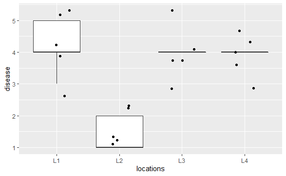

#Performing tests -Specify the formula of the form a ~ b | c, where a (dependent variable), b (treatment) and c (blocks)

```r
# same as friedman.test(y = df_long$disease, groups = df_long$locations, blocks = df_long$plant_var)
 friedman.test(formula = disease ~ locations | plant_var, data = df_long)
```

```
    Friedman rank sum test

data:  disease and locations and plant_var
Friedman chi-squared = 9.8478, df = 3, p-value = 0.0199
```

*Although the friedman’s test indicates that there are significant differences in disease severity in plant varieties based on locations but does not tell which locations have a significant effect on disease severity.To know which locations are significantly different, we perform the conover’s test

```r
#library(PMCMRplus)
frdAllPairsConoverTest(y = df_long$disease, groups = df_long$locations,
                        blocks = df_long$plant_var, p.adjust.method = "bonf")
```

```
    Pairwise comparisons using Conover's all-pairs test for a two-way balanced complete block design

data: y, groups and blocks
```

```
   L1   L2   L3
L2 0.13 -    -
L3 1.00 0.17 -
L4 1.00 0.21 1.00
```

```
P value adjustment method: bonferroni
```